# Project 5

Daniel Izaguirre

November 8, 2016

## Preface

```r
data <- data.frame(ToothGrowth)
```

```r
head(data)
```

```
##    len supp dose dosage
## 1  4.2   VC  0.5    Low
## 2 11.5   VC  0.5    Low
## 3  7.3   VC  0.5    Low
## 4  5.8   VC  0.5    Low
## 5  6.4   VC  0.5    Low
## 6 10.0   VC  0.5    Low
```

The “ToothGrowth” data set shows the effect of vitamin c on the growth of teeth in guinea pigs. There are 3 dosage amounts being used in the set: 0.5 mg/day (Low), 1.0 mg/day (Moderate), 2.0 mg/day (High). Additionally there are two delivery methods, orange juice (oj) and ascorbic acid (vc).

```r
str(data)
```

```
## 'data.frame':    60 obs. of  4 variables:
##  $ len   : num  4.2 11.5 7.3 5.8 6.4 10 11.2 11.2 5.2 7 ...
##  $ supp  : Factor w/ 2 levels "OJ","VC": 2 2 2 2 2 2 2 2 2 2 ...
##  $ dose  : num  0.5 0.5 0.5 0.5 0.5 0.5 0.5 0.5 0.5 0.5 ...
##  $ dosage: chr  "Low" "Low" "Low" "Low" ...
```

## Plots

#### By delivery method of supplement:

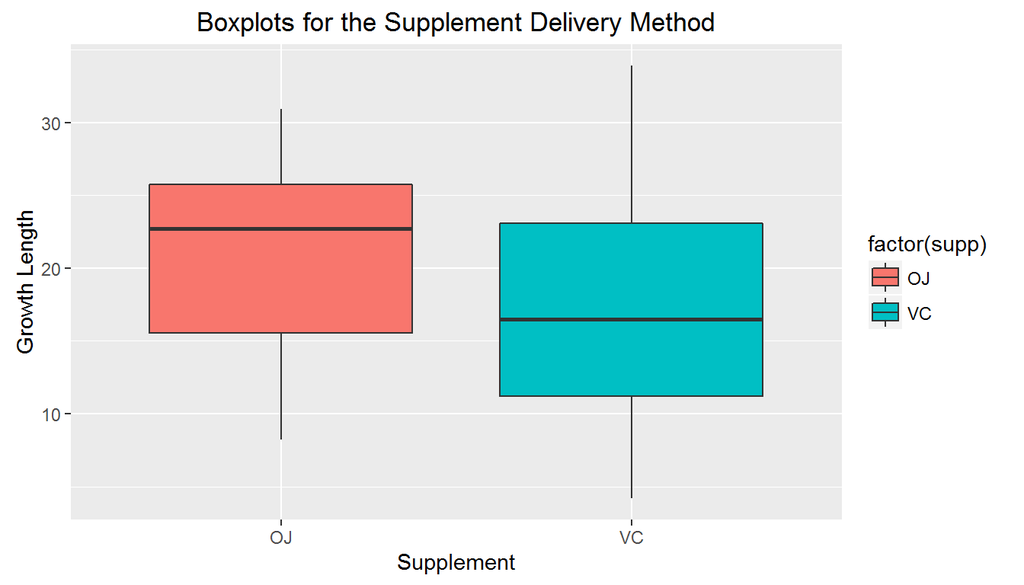

```r
data_plot1
```

The orange juice supplement produces a higher mean tooth growth. However the ascorbic acid produces a wider spread of possible lengths.

#### By dosage:

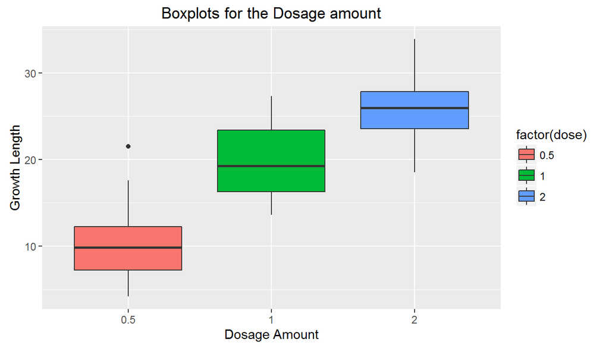

```r
data_plot2
```

The high dosage amount produces the greatest amount of tooth length growth. While there is a relative decrease in effectiveness with lowering amounts of dosage.

#### By both variables combined:

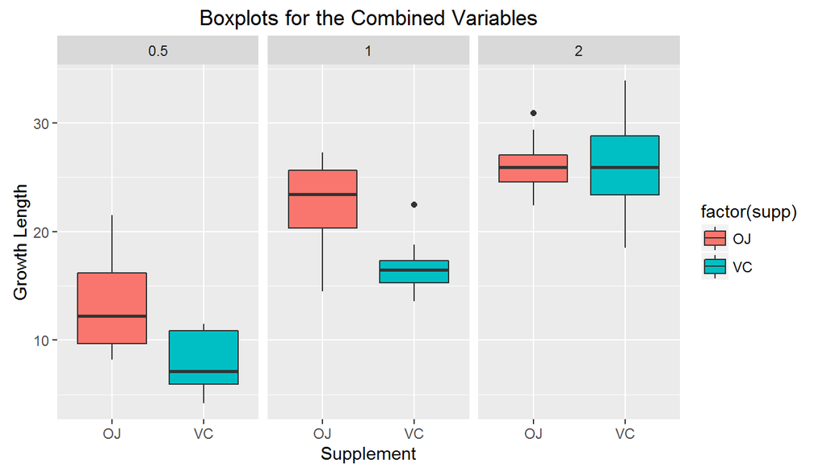

```r
data_plot3
```

From the combined graphs, the trend of growth increases with increasing dosage increments in both supplements. So,the highest dosage amount produces the most growth. It actually seems to be that dosage amount has a strong influence in tooth growth. However until the high dosage of 2.0 mg/day, the orange juice seems to be better than ascorbic acid to produce growth.

## Confidence Intervals

#### Guinea pigs who receive a supplement as ascorbic acid (any dosage)

```r
data_vc <- data %>%
  filter(supp == "VC")
t_test_vc <- t.test(data_vc$len, conf.level = .95)
conf_vc <- t_test_vc$conf.int
conf_vc
```

```
## [1] 13.87675 20.04992
## attr(,"conf.level")
## [1] 0.95
```

The confidence interval for the ascorbic acid observations is between 13.88 and 20.05.

#### Guinea pigs who receive 2 mg of the supplement, delivered via orange juice

```r
data_oj <- data %>%
  filter(supp == "OJ") %>%
  filter(dosage == "High")
t_test_oj <- t.test(data_oj$len, conf.level = .95)
conf_oj <- t_test_oj$conf.int
conf_oj
```

```
## [1] 24.16069 27.95931
## attr(,"conf.level")
## [1] 0.95
```

The confidence interval for the orange juice observations is between 24.16 and 27.96.

## T-test Comparisons of various samples

Ha: The growth of teeth is not equal when the supplements is ascorbic acid or orange juice.

```r
test1 <- t.test(data_vc$len, data_oj$len)
test1
```

```
##
##  Welch Two Sample t-test
##
## data:  data_vc$len and data_oj$len
## t = -5.2673, df = 38, p-value = 5.744e-06
## alternative hypothesis: true difference in means is not equal to 0
## 95 percent confidence interval:
##  -12.59278  -5.60055
## sample estimates:
## mean of x mean of y
##  16.96333  26.06000
```

#### Between guinea pigs who receive a 1 mg dose from orange juice and those who receive a 2 mg dose from orange juice (1-sided test)

Ho: A moderate amount of dosage will be equal to a high amount of dosage.

Ha: A moderate amount of dosage will be less than a high amount of dosage.

```r
data_2_oj_mod <- data %>%
  filter(supp == "OJ") %>%
  filter(dosage == "Moderate")
data_2_oj_high <- data %>%
  filter(supp == "OJ") %>%
  filter(dosage == "High")
test2 <- t.test(data_2_oj_mod$len, data_2_oj_high$len, alternative = "less")
test2
```

```
##
##  Welch Two Sample t-test
##
## data:  data_2_oj_mod$len and data_2_oj_high$len
## t = -2.2478, df = 15.842, p-value = 0.0196
## alternative hypothesis: true difference in means is less than 0
## 95 percent confidence interval:
##        -Inf -0.7486236
## sample estimates:
## mean of x mean of y
##     22.70     26.06
```

The p-value is significant, so the test rejects the null hypothesis. The 2 populations being compared are the guinea pigs that are given a moderate dosage of orange juice and a high dosage of orange juice. There is a difference, it is likely that a a moderate amount of dosage produces less growth than a high dosage.

#### Between guinea pigs who receive a 1 mg dose from ascorbic acid and those who receive a 2 mg dose from ascorbic acid (1-sided test)

Ho: A moderate dosage of ascorbic acid produces tooth growth equal to the high dosage of ascorbic acid.

Ha: A moderate dosage of ascorbic acid produces tooth growth less than the high dosage of ascorbic acid.

```r
data_3_vc_mod <- data %>%
  filter(supp == "VC") %>%
  filter(dosage == "Moderate")
data_3_vc_high <- data %>%
  filter(supp == "VC") %>%
  filter(dosage == "High")
test3 <- t.test(data_3_vc_mod$len, data_3_vc_high$len, alternative = "less")
test3
```

```
##
##  Welch Two Sample t-test
##
## data:  data_3_vc_mod$len and data_3_vc_high$len
## t = -5.4698, df = 13.6, p-value = 4.578e-05
## alternative hypothesis: true difference in means is less than 0
## 95 percent confidence interval:
##       -Inf -6.346525
## sample estimates:
## mean of x mean of y
##     16.77     26.14
```

The p-value is significant, so the test rejects the null hypothesis. The 2 populations being compared are the guinea pigs that are given a moderate dosage of ascorbic acid and a high dosage of ascorbic acid. The test suggests that there is a difference between the moderate dosage and the high dosage of ascorbic acid.

#### Between guinea pigs who receive a 1 mg dose from ascorbic acid and those who receive a 1 mg dose from orange juice (2-sided test)

Ho: A moderate dosage of ascorbic acid produces tooth growth equal to a moderate dosage of orange juice.

Ha: A moderate dosage of ascorbic acid produces tooth growth not equal to the moderate dosage of orange juice.

```r
data_4_vc_mod <- data %>%
  filter(supp=="VC") %>%
  filter(dosage=="Moderate")
data_4_oj_mod <- data %>%
  filter(supp=="OJ") %>%
  filter(dosage=="Moderate")
test4 <- t.test(data_4_vc_mod$len,data_4_oj_mod$len)
test4
```

```
##
##  Welch Two Sample t-test
##
## data:  data_4_vc_mod$len and data_4_oj_mod$len
## t = -4.0328, df = 15.358, p-value = 0.001038
## alternative hypothesis: true difference in means is not equal to 0
## 95 percent confidence interval:
##  -9.057852 -2.802148
## sample estimates:
## mean of x mean of y
##     16.77     22.70
```

The p-value is significant, so the test rejects the null hypothesis. The 2 populations being compared are the guinea pigs that are given a moderate dosage of ascorbic acid and a moderate dosage of orange juice. The test suggests that there is a difference between the moderate dosage of ascorbic acid and moderate dosage of orange juice.

#### Between guinea pigs who receive a 2 mg dose from ascorbic acid and those who receive a 2 mg dose from orange juice (2-sided test)

Ho: A high dosage of ascorbic acid produces tooth growth equal to a high dosage of orange juice.

Ha: A high dosage of ascorbic acid produces tooth growth not equal to the high dosage of orange juice.

```r
data_5_vc_high <- data %>%
  filter(supp=="VC") %>%
  filter(dosage=="High")
data_5_oj_high <- data %>%
  filter(supp=="OJ") %>%
  filter(dosage=="High")
test5 <- t.test(data_5_vc_high$len,data_5_oj_high$len)
test5
```

```
##
##  Welch Two Sample t-test
##
## data:  data_5_vc_high$len and data_5_oj_high$len
## t = 0.046136, df = 14.04, p-value = 0.9639
## alternative hypothesis: true difference in means is not equal to 0
## 95 percent confidence interval:
##  -3.63807  3.79807
## sample estimates:
## mean of x mean of y
##     26.14     26.06
```

The p-value is not significant, so the test fails to reject the null hypothesis. The 2 populations being compared are the guinea pigs that are given a high dosage of ascorbic acid and a high dosage of orange juice. The test suggests that there is no significant difference between the high dosage of ascorbic acid and high dosage of orange juice.